# 3.1

Manish Shah

2023-04-22

## 1. Create a barplot of cyl variable of mtcars data with and without using factor argument

Without factor argument

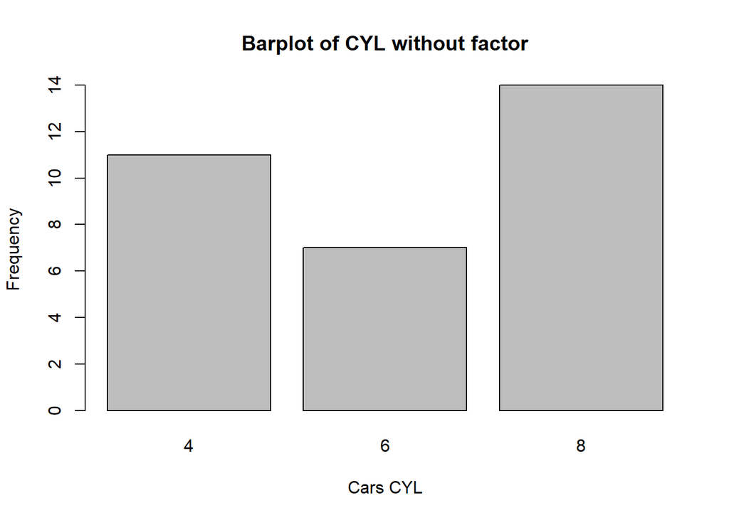

```r
data(mtcars)
barplot(table(mtcars$cyl), xlab="Cars CYL", ylab="Frequency", main="Barplot of CYL without factor")
```

With factor argument

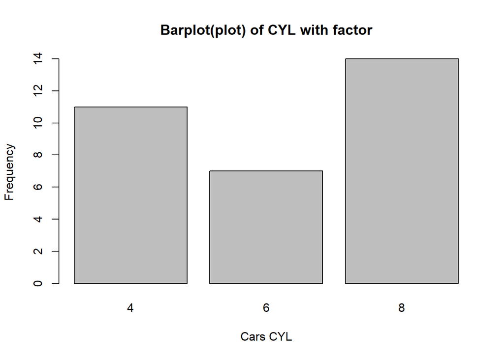

```r
plot(as.factor(mtcars$cyl), xlab="Cars CYL", ylab="Frequency", main="Barplot(plot) of CYL with factor")
```

## 2. Locate median of mpg variable of mtcars data graphically and compare the median value with in-built function of R

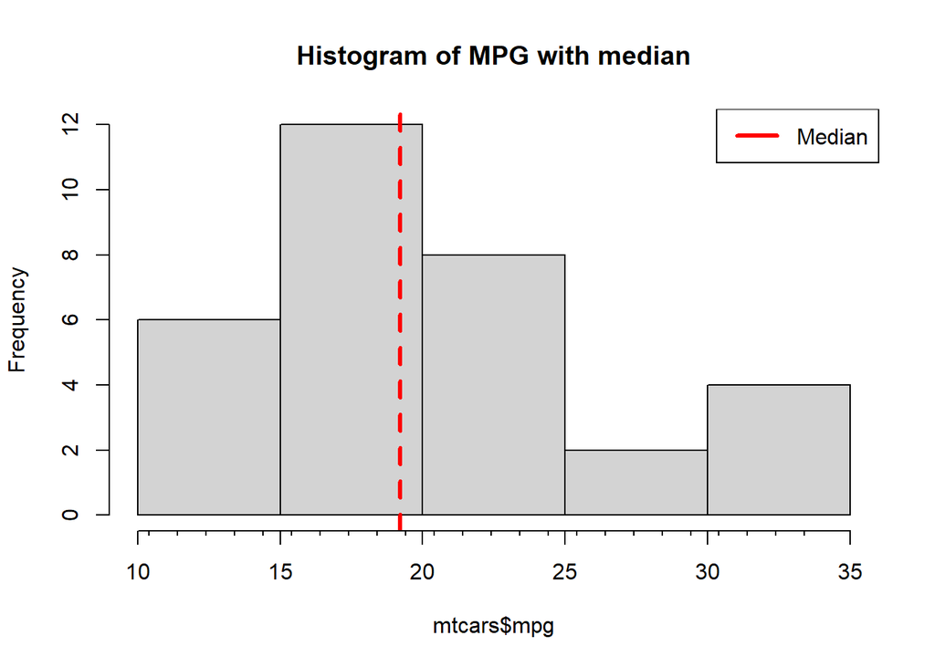

```r
hist(mtcars$mpg, main="Histogram of MPG with median")
abline(v=median(mtcars$mpg), lwd=3, lty=2, col="red")
legend("topright", legend="Median", col="red", lwd=3)
axis(side = 1, at = seq(min(mtcars$mpg), max(mtcars$mpg), by = 1), tck = -0.01, labels = FALSE)
```

Median value of mpg from in-built function of R

```r
median(mtcars$mpg)
```

```
## [1] 19.2
```

*We can the same value from graph & from median function i.e. 19.2*

## 3. Locate mode of mpg variable of mtcars data graphically and compare the mode value with the in-built/custom function of R

```r
mode <- 3*median(mtcars$mpg) - 2*mean(mtcars$mpg)
mode
```

```
## [1] 17.41875
```

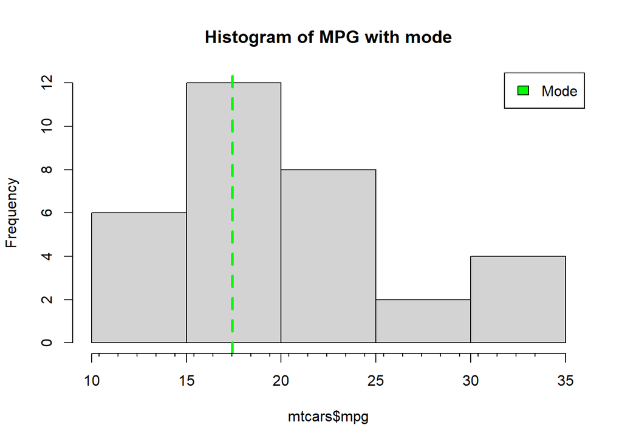

```r
hist(mtcars$mpg, main="Histogram of MPG with mode")
abline(v=mode, lwd=3, lty=2, col="green")
axis(side = 1, at = seq(min(mtcars$mpg), max(mtcars$mpg), by = 1), tck = -0.01, labels = FALSE)
legend("topright", legend = "Mode", fill= "green")
```

From graph, we can notice mode falls in approx 17.5 and we have the calculated mode = 17.41875

## 4. Create a scatterplot of mgp (dependent) and wt (independent) variable of mtcars data, add ablines at mean plus-minus 2 standard deviation and show the name of the cars with mpg > 2 standard deviation from mean inside the scatterplot obtained above

```r
plot(mtcars$wt, mtcars$mpg, ylim=c(0,40), main = "Scatterplot of MPG and Weight", xlab = "Weight", ylab = "Miles per Gallon")

upper_lim <- mean(mtcars$mpg)+2*sd(mtcars$mpg)
lower_lim <- mean(mtcars$mpg)-2*sd(mtcars$mpg)

abline(h=upper_lim, lwd=2, lty=2, col="red")
abline(h=lower_lim, lwd=2, lty=2, col="red")

cat("Search cars with greater than upper_limit value & then use rownames() to get name of cars which will plot in the graph")
```

```
## Search cars with greater than upper_limit value & then use rownames() to get name of cars which will plot in the graph
```

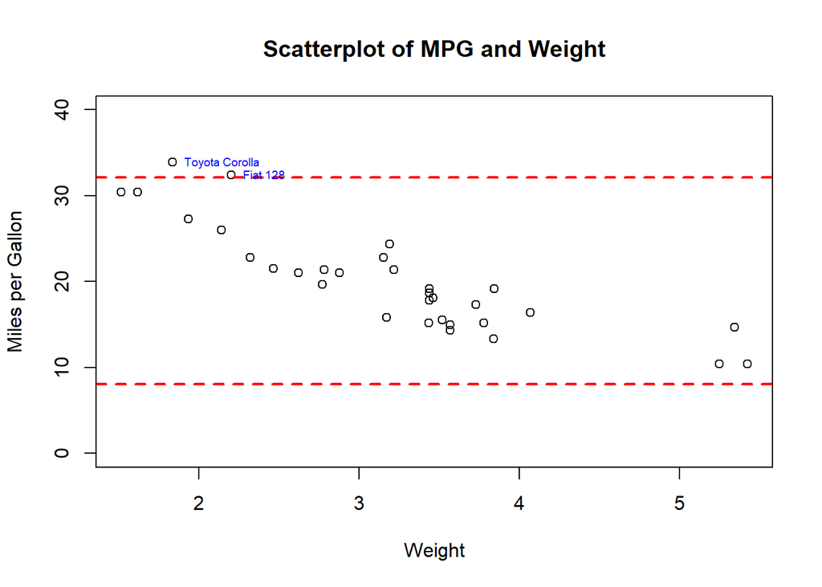

```r
text(mtcars$wt[mtcars$mpg > upper_lim], mtcars$mpg[mtcars$mpg > upper_lim], rownames(mtcars)[mtcars$mpg > upper_lim], cex = 0.6, pos=4, col="blue")
```

## 5. Create a x variable with 100 random numbers and y variable with x + 100 random numbers; create a factor variable with 100 monthly random observations, create a time series data with 100 random values starting from January 1970; create a date variable with 100 random values starting from 1970/01/01 increasing each day; create a new variable z with square of x variable

```r
set.seed(16)
```

Variable with 100 random numbers

```r
set.seed(16)
x <- sample(100, replace = TRUE)
```

Variable with x + 100 random numbers

```r
set.seed(16)
y <- x + sample(100, replace = TRUE)
```

Factor variable with 100 random month observation

```r
set.seed(16)
month <- factor(sample(month.name, 100, replace = TRUE))
```

Time series data starting from 1970 January

```r
set.seed(16)
ts_data <- ts(sample(1:100, 100, replace = TRUE), start = c(1970, 1), frequency = 12)
```

Date variable with 100 random values starting from 1970/01/01

```r
set.seed(16)
ts_date <- as.Date("1970/01/01") + sample(0:365, 100, replace = TRUE)
```

Square of x variable

```r
z <- x^2
```

Print all the variable created

```r
x
```

```
##   [1]  97  59  61  15  43   8  20  94  46  91  84  64  81  67  56  62  83  21
##  [19]  13  88  72  14  84  57  11  40  46  75  57  24  57  92  56  75  13  39
##  [37]  57  50   1  41  73   1  69  68  30  69  31  69  26  73  29   2  67  84
##  [55]  46  43   7  23  48   4   5   3  15  18  27  84  29  75  99  17  58  33
##  [73]  76  67  86  21  53  56  89  82  14  87  59 100  42   2  65  91  82  32
##  [91]  29  46  90  74  76  97  52  71  99  12
```

```r
y
```

```
##   [1] 194 118 122  30  86  16  40 188  92 182 168 128 162 134 112 124 166  42
##  [19]  26 176 144  28 168 114  22  80  92 150 114  48 114 184 112 150  26  78
##  [37] 114 100   2  82 146   2 138 136  60 138  62 138  52 146  58   4 134 168
##  [55]  92  86  14  46  96   8  10   6  30  36  54 168  58 150 198  34 116  66
##  [73] 152 134 172  42 106 112 178 164  28 174 118 200  84   4 130 182 164  64
##  [91]  58  92 180 148 152 194 104 142 198  24
```

```r
month
```

```
##   [1] January   November  November  August    April     November  April
##   [8] January   October   March     December  August    June      September
##  [15] March     May       August    August    April     May       September
##  [22] August    November  August    January   November  September August
##  [29] June      March     September June      December  November  August
##  [36] November  July      September September February  February  January
##  [43] September September January   May       April     May       May
##  [50] October   September February  March     April     September November
##  [57] July      July      April     May       March     August    February
##  [64] November  April     November  March     January   May       October
##  [71] January   December  March     July      June      May       May
##  [78] August    September February  July      September October   November
##  [85] April     October   February  January   November  November  July
##  [92] April     February  October   March     October   July      December
##  [99] January   April
## 12 Levels: April August December February January July June March ... September
```

```r
ts_data
```

```
##      Jan Feb Mar Apr May Jun Jul Aug Sep Oct Nov Dec
## 1970  97  59  61  15  43   8  20  94  46  91  84  64
## 1971  81  67  56  62  83  21  13  88  72  14  84  57
## 1972  11  40  46  75  57  24  57  92  56  75  13  39
## 1973  57  50   1  41  73   1  69  68  30  69  31  69
## 1974  26  73  29   2  67  84  46  43   7  23  48   4
## 1975   5   3  15  18  27  84  29  75  99  17  58  33
## 1976  76  67  86  21  53  56  89  82  14  87  59 100
## 1977  42   2  65  91  82  32  29  46  90  74  76  97
## 1978  52  71  99  12
```

```r
ts_date
```

```
##   [1] "1970-08-13" "1970-05-07" "1970-11-11" "1970-07-08" "1970-09-28"
##   [6] "1970-09-21" "1970-10-03" "1970-12-06" "1970-03-05" "1970-12-03"
##  [11] "1970-05-05" "1970-08-22" "1970-03-08" "1970-12-27" "1970-03-03"
##  [16] "1970-03-24" "1970-01-21" "1970-12-10" "1970-03-25" "1970-04-14"
##  [21] "1970-05-19" "1970-10-23" "1970-10-29" "1970-04-23" "1970-07-22"
##  [26] "1970-07-04" "1970-06-01" "1970-04-22" "1970-08-18" "1970-07-04"
##  [31] "1970-12-14" "1970-11-08" "1970-09-26" "1970-06-16" "1970-09-13"
##  [36] "1970-11-09" "1970-08-21" "1970-06-27" "1970-01-01" "1970-02-10"
##  [41] "1970-03-10" "1970-07-15" "1970-01-30" "1970-03-10" "1970-01-31"
##  [46] "1970-11-21" "1970-03-14" "1970-06-06" "1970-09-15" "1970-07-14"
##  [51] "1970-12-06" "1970-06-23" "1970-04-15" "1970-02-12" "1970-05-15"
##  [56] "1970-09-17" "1970-09-18" "1970-05-11" "1970-05-07" "1970-04-30"
##  [61] "1970-09-28" "1970-06-06" "1970-03-16" "1970-04-09" "1970-09-30"
##  [66] "1970-08-17" "1970-11-10" "1970-10-16" "1970-11-28" "1970-07-14"
##  [71] "1970-04-13" "1970-12-08" "1970-01-21" "1970-02-22" "1970-03-30"
##  [76] "1970-03-23" "1970-05-22" "1970-12-09" "1970-08-22" "1970-07-06"
##  [81] "1970-08-16" "1970-06-19" "1970-01-02" "1971-01-01" "1970-07-29"
##  [86] "1970-06-06" "1970-12-31" "1970-10-29" "1970-12-12" "1970-03-15"
##  [91] "1970-09-04" "1970-08-13" "1970-11-04" "1970-07-18" "1970-12-21"
##  [96] "1970-01-12" "1970-08-01" "1970-01-26" "1970-09-24" "1970-09-30"
```

```r
z
```

```
##   [1]  9409  3481  3721   225  1849    64   400  8836  2116  8281  7056  4096
##  [13]  6561  4489  3136  3844  6889   441   169  7744  5184   196  7056  3249
##  [25]   121  1600  2116  5625  3249   576  3249  8464  3136  5625   169  1521
##  [37]  3249  2500     1  1681  5329     1  4761  4624   900  4761   961  4761
##  [49]   676  5329   841     4  4489  7056  2116  1849    49   529  2304    16
##  [61]    25     9   225   324   729  7056   841  5625  9801   289  3364  1089
##  [73]  5776  4489  7396   441  2809  3136  7921  6724   196  7569  3481 10000
##  [85]  1764     4  4225  8281  6724  1024   841  2116  8100  5476  5776  9409
##  [97]  2704  5041  9801   144
```

## 6. Create a 2 x 3 plot window with scatterplot, barplot, boxplot, time series plot, date plot and square function plot

2x3 plot window

```r
par(mfrow=c(2,3))
cat('Scatter plot of x and y')
```

```
## Scatter plot of x and y
```

```r
plot(x, y, main = "Scatterplot of x and y", xlab = "x", ylab = "y")
cat('Bar plot of factor variable month')
```

```
## Bar plot of factor variable month
```

```r
barplot(table(month), main = "Barplot of month", xlab = "Month", ylab = "Frequency")
cat('Box plot of ts_data')
```

```
## Box plot of ts_data
```

```r
boxplot(ts_data, main = "Boxplot of ts_data")

cat('Time series plot of ts_data')
```

```
## Time series plot of ts_data
```

```r
plot(ts_data, main = "Time series plot of ts_data", xlab = "Year", ylab = "Value")

cat('Date plot of ts_date and y')
```

```
## Date plot of ts_date and y
```

```r
plot(ts_date, y, main = "Date plot of ts_date and y", xlab = "Date", ylab = "y")

cat('Plot of z vs x')
```

```
## Plot of z vs x
```

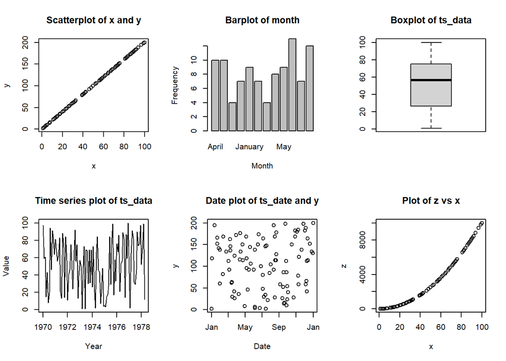

```r
plot(x, z, main = "Plot of z vs x", xlab = "x", ylab = "z")
```

```r
par(mfrow=c(1,1))
```

## 7. Perform log transformation on x and z variables i.e. log of x, log of z and log of x and z in the plot command and interpret the results carefully

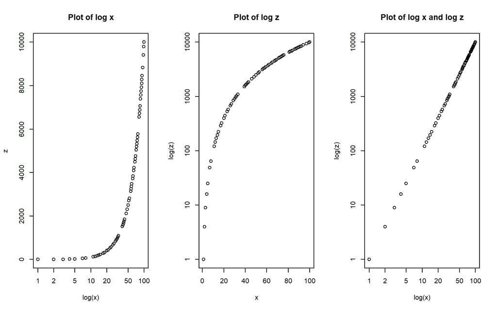

```r
par(mfrow = c(1,3))
plot(x, z, log="x", main = "Plot of log x", xlab = "log(x)", ylab = "z")
plot(x, z, log="y", main = "Plot of log z", xlab = "x", ylab = "log(z)")
plot(x, z, log="xy", main = "Plot of log x and log z", xlab = "log(x)", ylab = "log(z)")
par(mfrow = c(1,1))
```

It shows that there is linear relation when both x & z is log transformed. But when we do log transform separately, the distribution is not uniform & is heavily skewed.

## 8. Create a 1x1 plot window with correlation matrix plot of first three numerical variable of mtcars data (cyl is not numeric, its factor!)

Remove cyl variable

```r
library(dplyr)
mtcars_sub <- select(mtcars, -c(cyl))
```

Get first three numerical variables

```r
mtcars_sub <- mtcars_sub[, 1:3]
```

Create a correlation matrix

```r
cars_corr <- cor(mtcars_sub)
```

Plot correlation matrix

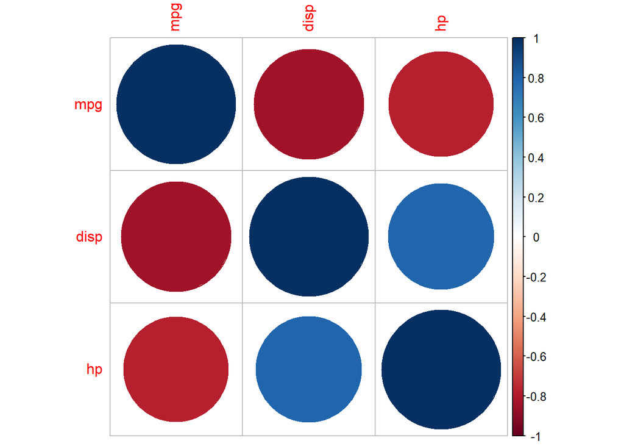

```r
library(corrplot)
corrplot(cars_corr, method = "circle")
```

## 9. Interpret the result of the correlation matrix plot obtained above with respect to the correlation coefficient to be used for each pair

From the correlation plot, we can observe that dark blue has highest correlation & dark red has lowest correlation.

## 10. Write advantage and limitations of plots created using R base packages based on these nine steps

Advantages - - The R base plot is already available without loading any package so we can use it easily. - The plots are customizable i.e. we can add lable, topics, ablines, etc. - It supports multiple types of graph such as boxplot, barplot, timeseries plot, scatter plot, etc.

Limitations - - It takes time to plot for variables containing large numbers of rows - It doesn’t supports complex graph which can be generated using ggplot2